# Final GNG RT analyses

PD Inhibition Project

Alison Schreiber, Nate Hall

5/5/2020

# Load data

Data has already been cleaned and initial analyses completed by NH. For RT analyses, use variable rt_log_trim_grp For outcome analyses, use response -> this indicates whether they correctly Go vs No Go’d (can figure out whether they pressed space or not based on the stim) Cond refers to number of prior go trials Stim refers whether go or no go trial Use trial_z rather than trial (for scaling purposes) Will likely add in prev_rt in more complex analyses

N.B. 6/22/20: Nate is going through alison’s analyses and converting to lme4 for consistency. This shouldn’t change things much. Update: I changed things a decent amount. Oops.

```r
#raw flanker data, all subjects
gng <- read.csv("~/github_repos/PD_Inhibition_DDM/Data/preprocessed/go_nogo_full_accCode.csv") %>% mutate(bad_subj = if_else(subj_idx == 15, 1, 0)) #flagged 15 as bad as this was the one person who needed to be according to NH's preprocessing; will test how inclusion of 15 alters results
gng <- mutate(gng, cond= factor(cond, levels = c("OneGo","ThreeGo", "FiveGo", "SevenGo")))

gng <- gng %>% group_by(subj_idx) %>% mutate(

                                      prev_rt = ifelse(lag(rt_log_trim_grp) == 0, NA, lag(rt_log_trim_grp)),

                                      prev_rt_z = scale(prev_rt),
                                      prev_error = ifelse(lag(response) == 1, 0, 1),
                                      id = as.character(subj_idx))


gng_rt <- dplyr::filter(gng, stim == "Go", response == 1) #only analyze GO RTs!
# gng_rt$cond_id <- with(gng_rt, interaction(cond,id))
gng_rt <- mutate(gng_rt, block_trial_z = scale(block_trial))
# View(gng_rt)


# test(emtrends(m19, ~trial_z, var = "block_trial_z", at = list(trial_z = c(-1, 1))))
# quantile(gng_rt$prev_rt, .16, na.rm = TRUE) # to get what is equivalent to -1, 1 in z scores
# quantile(gng_rt$prev_rt, .84, na.rm = TRUE)

unique(gng_rt$bad_subj)
```

```
## [1] 0
```

```r
render_aictab <- function(minfo, ...) {
  mc <- match.call(expand.dots = TRUE)
  mlist <- list(...)

  #N.B. AICtab fails if you try to assign names to the list names(mlist) <- ...
  mnames <- sapply(3:length(mc), function(x) { as.character(mc[[x]])})
  mdf <- do.call(rbind, minfo) %>% as.data.frame() %>% rownames_to_column("model")
  adf <- AICtab(mlist, sort=FALSE, delta=TRUE, weights=TRUE, logLik=TRUE, base=TRUE, mnames=mnames) %>%
    as.data.frame() %>% rownames_to_column("model") %>% dplyr::select(-dLogLik)

  res <- mdf %>% left_join(adf, by="model")
  return(res)
}

flextb_vif <- function(m) {
  flextable(data.frame(vif=car::vif(m)) %>% rownames_to_column("Predictor")) %>% autofit()
}

check_singularity <- function(lmerobj) {
  tt <- getME(lmerobj,"theta") #RE estimates
  ll <- getME(lmerobj,"lower") #lower bound on estimate

  #look for RE estimates that are very small (near zero) and the lower bound encompasses 0
  low_re <- tt[ll==0 & tt < 1e-2]
  return(low_re)

  #eventually, would be nice to provide functionality to drop these from model and refit automatically
}

minfo <- list() #used for building model summary table
```

# RT analyses (from AMS, NTH does things differently (perhaps in part due to not fitting fixed effects covariance structures for simplicity))

m1. trial and condition (1 Go as reference) predict RT with homogonous covariance estimated at the subject level m2. trial and condition predict RT with homogonous covariance estimated per subject and variance estimated separately per condition m3. trial and condition predict RT with homogonous covariance estimated per subject and variance estimated separately per condition and a random intercept estimated for each condition within each subject m4. trial and condition predict RT with homogonous covariance estimated for each condition within each subject and randon intercept estimated for each condition within each subject m5. trial and cond predict RT with homogonous covariance estimated for each condition, separate variance for each condition and a random intercept for each condition within each subject. Also, slope of trial on RT estimated for each condition within subject. m6. trial and cond predict RT with homogonous covariance estimated for each cond, separate variance for each condition and a random intercept for each condition within each subject. Also, slope of trial on RT estimated for each subject. m7. trialcond predict RT with homogonous covariance structure within subject and variance estimated separatey per condition and a random intercept for each each condition within subject. Also, slope of trial on RT estimated for each subject.  
m8. trialcond predict RT with homogonous covariance structure within subject and variance estimated separatey per condition and a random intercept for each each condition within subject. Also, slope of trial on RT estimated for each condition within subject.  
m9. Rather than think of it in terms of trials *condition, instead frame as block_trial*trial effect. In this case, trial within block by trial predict RT. Homogonous covariance structure within subject and variance estimated by condition. Random intercepts and slope of trial for each condition within subject. m10. block_trial*trial effect on RT with homogonous variance and covariance structure within subject and random intercept and slope of block trial estimated for each subject. m11. block_trial and trial and cond effects on RT with homogonous covariance and variance estimated per condition. Random intercepts and slope of trial for each condition with subject. m12. maybe cond is redundnat with both block trial and cond? block trial and trial effects on RT. homogonous covariance structure estiamted per subject and variance estimated per cond. Random intercept and slope of trial estmimated for each condition within subject. m13. block trial*trial effects on RT. homogonous covariance structure estiamted per subject and variance estimated per cond. Random intercept and slope of trial estmimated for each condition within subject. m14. block trial*trial effects on RT. homogonous covariance structure estiamted per subject and variance estimated per cond. Random intercept and slopes of trial and block_trial estmimated for each condition within subject. m15. block trial*trial effects on RT. homogonous covariance structure estiamted per subject and variance estimated per cond. Random intercept and slope of trial and block_trial estmimated for each subject. Random slope of block trial estimated per condition within subject. m16. block trial*trial effects on RT. homogonous covariance structure estiamted per subject and variance estimated per cond. Random intercept and slope of trial and block_trial estmimated for each subject. Random slope of trial estimated per condition within subject. m17. block trial*trial effects on RT. homogonous covariance structure estiamted per subject and variance estimated per cond. Random intercept and slope of trial, block_trial, and cond estmimated for each subject. m18. block trial*trial and prev rt effects on RT. homogonous covariance structure estiamted per subject and variance estimated per cond. Random intercept and slope of trial and block_trial estimated for each subject. Random slope of block trial estimated per condition within subject. m19. FAVORITE! block trial*trial and prev_rtXblock_trial effects on RT. homogonous covariance structure estimated per subject and variance estimated per cond. Random intercept and slope of trial and block_trial estmimated for each subject. Random slope of block trial estimated per condition within subject. m20. block trial*trial and prev_rtXblock_trial effects on RT. homogonous covariance structure estimated per subject and variance estimated per cond. Random intercept and slope of trial, block_trial and prev rt estmimated for each subject. Random slope of block trial estimated per condition within subject. m21. block trial*trial and prev_rtXblock_trial effects on RT. homogonous covariance structure estimated per subject and variance estimated per cond. Random intercept and slopes of trial, block_trial and cond estmimated for each subject. Random slope of block trial estimated per condition within subject. m22. trial and prev_rt effects on RT. homogonous covariance structure estimated per subject and variance estimated per cond. Random intercept and slopes of trial and block_trial estmimated for each subject. Random slope of block trial estimated per condition within subject. m23. block trial*trial and prev_rtXblock_trial effects on RT. homogonous covariance structure estimated per subject and variance estimated per cond. Random intercept and slope of trial estmimated for each subject. Random slope of block trial estimated per condition within subject. m24. trial cond and prev_rt effects on RT. homogonous covariance structure estimated per subject and variance estimated per cond. Random intercept and slopes of trial estmimated for each subject. Random slope of prev rt estimated per condition within subject.

## m1: random intercept of subject, fixed = just condition

```r
# m1 <- lme(rt_log_trim_grp ~ trial_z + cond, random = ~ 1 | id,
#           correlation=corCompSymm(form=~trial|id), na.action = na.exclude,
#           data = gng_rt, method='ML')
#
# summary(m1)
# emmeans(m1, ~cond)

minfo[["m1"]] <- c(fixed="Condition", l2="Subject: Intercept")

m1 <- lmer(rt_log_trim_grp ~ cond + (1 | id),
           na.action = na.exclude,
          data = gng_rt)
summary(m1)
```

```
## Linear mixed model fit by REML. t-tests use Satterthwaite's method ['lmerModLmerTest']
## Formula: rt_log_trim_grp ~ cond + (1 | id)
##    Data: gng_rt
##
## REML criterion at convergence: -47175
##
## Scaled residuals:
##    Min     1Q Median     3Q    Max
## -3.996 -0.640 -0.072  0.576  3.993
##
## Random effects:
##  Groups   Name        Variance Std.Dev.
##  id       (Intercept) 0.00144  0.0379
##  Residual             0.00493  0.0702
## Number of obs: 19244, groups:  id, 103
##
## Fixed effects:
##             Estimate Std. Error       df t value Pr(>|t|)
## (Intercept) 2.54e+00   4.25e-03 1.65e+02  597.29  < 2e-16 ***
## condThreeGo 5.15e-03   2.34e-03 1.91e+04    2.20  0.02795 *
## condFiveGo  6.11e-03   2.23e-03 1.91e+04    2.75  0.00604 **
## condSevenGo 8.40e-03   2.17e-03 1.91e+04    3.87  0.00011 ***
## ---
## Signif. codes:  0 '***' 0.001 '**' 0.01 '*' 0.05 '.' 0.1 ' ' 1
##
## Correlation of Fixed Effects:
##             (Intr) cndThG cndFvG
## condThreeGo -0.415
## condFiveGo  -0.437  0.792
## condSevenGo -0.448  0.811  0.855
```

```r
# emmeans(m1, ~cond)


m1_reml <- update(m1, REML=TRUE)
emmeans(m1_reml, ~cond)
```

```
## Note: D.f. calculations have been disabled because the number of observations exceeds 3000.
## To enable adjustments, add the argument 'pbkrtest.limit = 19244' (or larger)
## [or, globally, 'set emm_options(pbkrtest.limit = 19244)' or larger];
## but be warned that this may result in large computation time and memory use.
```

```
## Note: D.f. calculations have been disabled because the number of observations exceeds 3000.
## To enable adjustments, add the argument 'lmerTest.limit = 19244' (or larger)
## [or, globally, 'set emm_options(lmerTest.limit = 19244)' or larger];
## but be warned that this may result in large computation time and memory use.
```

```
##  cond    emmean      SE  df asymp.LCL asymp.UCL
##  OneGo    2.539 0.00425 Inf     2.530     2.547
##  ThreeGo  2.544 0.00391 Inf     2.536     2.552
##  FiveGo   2.545 0.00384 Inf     2.537     2.552
##  SevenGo  2.547 0.00381 Inf     2.540     2.555
##
## Degrees-of-freedom method: asymptotic
## Confidence level used: 0.95
```

```r
# flextable(anova(m1) %>% tibble::rownames_to_column("Effect")) %>% autofit() #lmerTest reports Satterthwaite degrees of freedom
#flextable(car::Anova(m1, type=3)) %>% autofit()


# 1/(gng_rt$rt_log_trim_grp)

#Get model-predicted means in original RT scale. Force back onto original RT using custom function
# rg <- update(ref_grid(m1_reml), tran=list(linkinv=function(x) { (10^x)}, mu.eta=function(x) { 10^(x)}), predict.type="response")
#  # mu.eta=function(x) { 1/exp(x)}),
# res_trans <- emmeans(rg, ~cond, lmer.df = "satterthwaite") #this seems off, but consult with MH. got it working after i realized we transformed with log base 10.

# emmeans(m1_reml, ~cond|block, lmer.df = "satterthwaite") #in inverse units

# flextable(as.data.frame(res_trans)) %>%
#   colformat_num(j=c("response", "SE", "lower.CL", "upper.CL"), digits=2) %>%
#   autofit() #%>% save_as_docx(path = "~/Desktop/emmeans_gng_rt_conditions.docx")
```

## m2: random intercept of subject, slope of condition, fixed: condition

starting point in ML: random intercept of subject, compound symmetry residual correlation structure wrt trial

```r
# m1 <- lme(rt_log_trim_grp ~ trial_z + cond, random = ~ 1 | id,
#           correlation=corCompSymm(form=~trial|id), na.action = na.exclude,
#           data = gng_rt, method='ML')
#
# summary(m1)
# emmeans(m1, ~cond)

minfo[["m2"]] <- c(fixed="Condition", l2="Subject: Intercept, Condition")

m2 <- lmer(rt_log_trim_grp ~ cond + (1 + cond | id),
           na.action = na.exclude,
          data = gng_rt)
summary(m2)
```

```
## Linear mixed model fit by REML. t-tests use Satterthwaite's method ['lmerModLmerTest']
## Formula: rt_log_trim_grp ~ cond + (1 + cond | id)
##    Data: gng_rt
##
## REML criterion at convergence: -47206
##
## Scaled residuals:
##    Min     1Q Median     3Q    Max
## -3.970 -0.637 -0.073  0.576  4.018
##
## Random effects:
##  Groups   Name        Variance Std.Dev. Corr
##  id       (Intercept) 0.001790 0.0423
##           condThreeGo 0.000245 0.0157   -0.43
##           condFiveGo  0.000291 0.0171   -0.45  0.88
##           condSevenGo 0.000282 0.0168   -0.43  0.81  0.86
##  Residual             0.004889 0.0699
## Number of obs: 19244, groups:  id, 103
##
## Fixed effects:
##             Estimate Std. Error       df t value Pr(>|t|)
## (Intercept) 2.54e+00   4.64e-03 1.01e+02  547.69   <2e-16 ***
## condThreeGo 5.11e-03   2.80e-03 1.00e+02    1.83   0.0709 .
## condFiveGo  6.08e-03   2.78e-03 1.00e+02    2.18   0.0313 *
## condSevenGo 8.37e-03   2.73e-03 9.95e+01    3.07   0.0028 **
## ---
## Signif. codes:  0 '***' 0.001 '**' 0.01 '*' 0.05 '.' 0.1 ' ' 1
##
## Correlation of Fixed Effects:
##             (Intr) cndThG cndFvG
## condThreeGo -0.529
## condFiveGo  -0.563  0.819
## condSevenGo -0.559  0.811  0.858
## convergence code: 0
## Model failed to converge with max|grad| = 0.00451903 (tol = 0.002, component 1)
```

```r
# emmeans(m2, ~cond)


# m1_reml <- update(m1, REML=TRUE)
```

```r
flextable(anova(m2) %>% rownames_to_column("Effect")) %>% autofit() #lmerTest reports Satterthwaite degrees of freedom
```

| Effect | Sum Sq | Mean Sq | NumDF | DenDF | F value | Pr(>F) |
| --- | --- | --- | --- | --- | --- | --- |
| cond | 0.0534 | 0.0178 | 3 | 101 | 3.64 | 0.0153 |

```r
#flextable(car::Anova(m1, type=3)) %>% autofit()

flextable(render_aictab(minfo=minfo, m1, m2)) %>% autofit()
```

| model | fixed | l2 | logLik | AIC | dAIC | df | weight |
| --- | --- | --- | --- | --- | --- | --- | --- |
| m1 | Condition | Subject: Intercept | 23588 | -47163 | 12.2 | 6 | 0.00218 |
| m2 | Condition | Subject: Intercept, Condition | 23603 | -47176 | 0.0 | 15 | 0.99782 |

## m3: random intercept of subject, slope of condition, fixed: condition, trial

```r
# m1 <- lme(rt_log_trim_grp ~ trial_z + cond, random = ~ 1 | id,
#           correlation=corCompSymm(form=~trial|id), na.action = na.exclude,
#           data = gng_rt, method='ML')
#
# summary(m1)
# emmeans(m1, ~cond)

minfo[["m3"]] <- c(fixed="Condition, Trial", l2="Subject: Intercept, Condition")

m3 <- lmer(rt_log_trim_grp ~ cond + trial_z + (1 + cond | id),
           na.action = na.exclude,
          data = gng_rt)
```

```
## boundary (singular) fit: see ?isSingular
```

```r
summary(m3)
```

```
## Linear mixed model fit by REML. t-tests use Satterthwaite's method ['lmerModLmerTest']
## Formula: rt_log_trim_grp ~ cond + trial_z + (1 + cond | id)
##    Data: gng_rt
##
## REML criterion at convergence: -47188
##
## Scaled residuals:
##    Min     1Q Median     3Q    Max
## -3.936 -0.640 -0.072  0.578  3.989
##
## Random effects:
##  Groups   Name        Variance Std.Dev. Corr
##  id       (Intercept) 1.63e-03 0.04042
##           condThreeGo 4.91e-06 0.00222  -1.00
##           condFiveGo  8.68e-05 0.00932  -0.38  0.38
##           condSevenGo 1.07e-04 0.01037  -0.33  0.33  0.60
##  Residual             4.90e-03 0.07000
## Number of obs: 19244, groups:  id, 103
##
## Fixed effects:
##             Estimate Std. Error       df t value Pr(>|t|)
## (Intercept) 2.54e+00   4.47e-03 1.02e+02  568.09  < 2e-16 ***
## condThreeGo 5.13e-03   2.35e-03 4.03e+03    2.19  0.02888 *
## condFiveGo  6.11e-03   2.40e-03 1.92e+02    2.54  0.01181 *
## condSevenGo 8.39e-03   2.39e-03 1.16e+02    3.50  0.00065 ***
## trial_z     1.04e-03   5.04e-04 1.89e+04    2.07  0.03851 *
## ---
## Signif. codes:  0 '***' 0.001 '**' 0.01 '*' 0.05 '.' 0.1 ' ' 1
##
## Correlation of Fixed Effects:
##             (Intr) cndThG cndFvG cndSvG
## condThreeGo -0.474
## condFiveGo  -0.514  0.742
## condSevenGo -0.510  0.744  0.813
## trial_z      0.002 -0.001  0.000 -0.002
## convergence code: 0
## boundary (singular) fit: see ?isSingular
```

```r
# emmeans(m2, ~cond)


# m1_reml <- update(m1, REML=TRUE)


flextable(anova(m3) %>% rownames_to_column("Effect")) %>% autofit() #lmerTest reports Satterthwaite degrees of freedom
```

| Effect | Sum Sq | Mean Sq | NumDF | DenDF | F value | Pr(>F) |
| --- | --- | --- | --- | --- | --- | --- |
| cond | 0.0626 | 0.0209 | 3 | 128 | 4.26 | 0.00664 |
| trial_z | 0.0210 | 0.0210 | 1 | 18945 | 4.28 | 0.03851 |

```r
#flextable(car::Anova(m1, type=3)) %>% autofit()

flextable(render_aictab(minfo=minfo, m1, m2, m3)) %>% autofit()
```

| model | fixed | l2 | logLik | AIC | dAIC | df | weight |
| --- | --- | --- | --- | --- | --- | --- | --- |
| m1 | Condition | Subject: Intercept | 23588 | -47163 | 12.2 | 6 | 2.18e-03 |
| m2 | Condition | Subject: Intercept, Condition | 23603 | -47176 | 0.0 | 15 | 9.98e-01 |
| m3 | Condition, Trial | Subject: Intercept, Condition | 23594 | -47156 | 19.2 | 16 | 6.72e-05 |

## m4: random intercept of subject, slope of condition, fixed: condition, trials from no-go

```r
# m1 <- lme(rt_log_trim_grp ~ trial_z + cond, random = ~ 1 | id,
#           correlation=corCompSymm(form=~trial|id), na.action = na.exclude,
#           data = gng_rt, method='ML')
#
# summary(m1)
# emmeans(m1, ~cond)

minfo[["m4"]] <- c(fixed="Condition, Trials from no-go", l2="Subject: Intercept, Condition")

m4 <- lmer(rt_log_trim_grp ~ cond + block_trial_z + (1 + cond | id),
           na.action = na.exclude,
          data = gng_rt, control=lmerControl(optCtrl=list(maxfun=2e4))) #bump up iterations)
summary(m4)
```

```
## Linear mixed model fit by REML. t-tests use Satterthwaite's method ['lmerModLmerTest']
## Formula: rt_log_trim_grp ~ cond + block_trial_z + (1 + cond | id)
##    Data: gng_rt
## Control: lmerControl(optCtrl = list(maxfun = 20000))
##
## REML criterion at convergence: -47201
##
## Scaled residuals:
##    Min     1Q Median     3Q    Max
## -3.944 -0.638 -0.072  0.578  3.978
##
## Random effects:
##  Groups   Name        Variance Std.Dev. Corr
##  id       (Intercept) 0.001791 0.0423
##           condThreeGo 0.000246 0.0157   -0.43
##           condFiveGo  0.000292 0.0171   -0.45  0.88
##           condSevenGo 0.000283 0.0168   -0.43  0.81  0.86
##  Residual             0.004887 0.0699
## Number of obs: 19244, groups:  id, 103
##
## Fixed effects:
##               Estimate Std. Error       df t value Pr(>|t|)
## (Intercept)   2.54e+00   4.67e-03 1.04e+02  543.85   <2e-16 ***
## condThreeGo   4.32e-03   2.81e-03 1.02e+02    1.53   0.1283
## condFiveGo    4.49e-03   2.83e-03 1.08e+02    1.58   0.1164
## condSevenGo   5.98e-03   2.84e-03 1.17e+02    2.10   0.0376 *
## block_trial_z 1.68e-03   5.63e-04 1.88e+04    2.98   0.0029 **
## ---
## Signif. codes:  0 '***' 0.001 '**' 0.01 '*' 0.05 '.' 0.1 ' ' 1
##
## Correlation of Fixed Effects:
##             (Intr) cndThG cndFvG cndSvG
## condThreeGo -0.535
## condFiveGo  -0.572  0.819
## condSevenGo -0.567  0.801  0.862
## block_trl_z  0.122 -0.095 -0.188 -0.283
## convergence code: 0
## Model failed to converge with max|grad| = 0.00371471 (tol = 0.002, component 1)
```

```r
# emmeans(m2, ~cond)
```

## m5: remove condition and just fit trials from nogo

```r
minfo[["m5"]] <- c(fixed="Trials from no-go", l2="Subject: Intercept, Condition")

m5 <- lmer(rt_log_trim_grp ~  block_trial_z + (1 + cond | id),
           na.action = na.exclude,
          data = gng_rt, control=lmerControl(optCtrl=list(maxfun=2e4))) #bump up iterations)
```

```
## boundary (singular) fit: see ?isSingular
```

```r
summary(m5)
```

```
## Linear mixed model fit by REML. t-tests use Satterthwaite's method ['lmerModLmerTest']
## Formula: rt_log_trim_grp ~ block_trial_z + (1 + cond | id)
##    Data: gng_rt
## Control: lmerControl(optCtrl = list(maxfun = 20000))
##
## REML criterion at convergence: -47220
##
## Scaled residuals:
##    Min     1Q Median     3Q    Max
## -3.927 -0.638 -0.071  0.576  3.972
##
## Random effects:
##  Groups   Name        Variance Std.Dev. Corr
##  id       (Intercept) 1.65e-03 0.04057
##           condThreeGo 5.58e-06 0.00236  -1.00
##           condFiveGo  8.65e-05 0.00930  -0.40  0.40
##           condSevenGo 1.12e-04 0.01058  -0.34  0.34  0.61
##  Residual             4.90e-03 0.06999
## Number of obs: 19244, groups:  id, 103
##
## Fixed effects:
##               Estimate Std. Error       df t value Pr(>|t|)
## (Intercept)   2.55e+00   3.75e-03 1.02e+02  679.55   <2e-16 ***
## block_trial_z 2.09e-03   5.25e-04 5.21e+03    3.98    7e-05 ***
## ---
## Signif. codes:  0 '***' 0.001 '**' 0.01 '*' 0.05 '.' 0.1 ' ' 1
##
## Correlation of Fixed Effects:
##             (Intr)
## block_trl_z -0.016
## convergence code: 0
## boundary (singular) fit: see ?isSingular
```

```r
# emmeans(m2, ~cond)



# flextable(render_aictab(minfo=minfo, m1, m2, m3)) %>% autofit()
```

## m6: remove condition random effect and just fit trials from nogo

```r
minfo[["m6"]] <- c(fixed="Trials from no-go", l2="Subject: Intercept")

m6 <- lmer(rt_log_trim_grp ~  block_trial_z + (1| id),
           na.action = na.exclude,
          data = gng_rt, control=lmerControl(optCtrl=list(maxfun=2e4)), REML = FALSE) #bump up iterations)
summary(m6)
```

```
## Linear mixed model fit by maximum likelihood . t-tests use Satterthwaite's method ['lmerModLmerTest']
## Formula: rt_log_trim_grp ~ block_trial_z + (1 | id)
##    Data: gng_rt
## Control: lmerControl(optCtrl = list(maxfun = 20000))
##
##      AIC      BIC   logLik deviance df.resid
##   -47212   -47181    23610   -47220    19240
##
## Scaled residuals:
##    Min     1Q Median     3Q    Max
## -3.964 -0.639 -0.072  0.575  3.983
##
## Random effects:
##  Groups   Name        Variance Std.Dev.
##  id       (Intercept) 0.00142  0.0377
##  Residual             0.00493  0.0702
## Number of obs: 19244, groups:  id, 103
##
## Fixed effects:
##               Estimate Std. Error       df t value Pr(>|t|)
## (Intercept)   2.55e+00   3.75e-03 1.03e+02  679.09  < 2e-16 ***
## block_trial_z 2.25e-03   5.07e-04 1.91e+04    4.44  9.2e-06 ***
## ---
## Signif. codes:  0 '***' 0.001 '**' 0.01 '*' 0.05 '.' 0.1 ' ' 1
##
## Correlation of Fixed Effects:
##             (Intr)
## block_trl_z 0.000
```

```r
# emmeans(m2, ~cond)



flextable(render_aictab(minfo=minfo, m1, m2, m3,m4,m5,m6)) %>% autofit()
```

| model | fixed | l2 | logLik | AIC | dAIC | df | weight |
| --- | --- | --- | --- | --- | --- | --- | --- |
| m1 | Condition | Subject: Intercept | 23588 | -47163 | 48.7 | 6 | 2.66e-11 |
| m2 | Condition | Subject: Intercept, Condition | 23603 | -47176 | 36.4 | 15 | 1.22e-08 |
| m3 | Condition, Trial | Subject: Intercept, Condition | 23594 | -47156 | 55.7 | 16 | 8.19e-13 |
| m4 | Condition, Trials from no-go | Subject: Intercept, Condition | 23601 | -47169 | 42.7 | 16 | 5.34e-10 |
| m5 | Trials from no-go | Subject: Intercept, Condition | 23610 | -47194 | 18.0 | 13 | 1.24e-04 |
| m6 | Trials from no-go | Subject: Intercept | 23610 | -47212 | 0.0 | 4 | 1.00e+00 |

## m7: add trials from no-go as random effect

```r
minfo[["m7"]] <- c(fixed="Trials from no-go", l2="Subject: Intercept, Trials from no-go")

m7 <- lmer(rt_log_trim_grp ~  block_trial_z + (1 + block_trial_z | id),
           na.action = na.exclude,
          data = gng_rt, control=lmerControl(optCtrl=list(maxfun=2e4)), REML = FALSE) #bump up iterations)
summary(m7)
```

```
## Linear mixed model fit by maximum likelihood . t-tests use Satterthwaite's method ['lmerModLmerTest']
## Formula: rt_log_trim_grp ~ block_trial_z + (1 + block_trial_z | id)
##    Data: gng_rt
## Control: lmerControl(optCtrl = list(maxfun = 20000))
##
##      AIC      BIC   logLik deviance df.resid
##   -47530   -47483    23771   -47542    19238
##
## Scaled residuals:
##    Min     1Q Median     3Q    Max
## -3.828 -0.637 -0.079  0.570  4.189
##
## Random effects:
##  Groups   Name          Variance Std.Dev. Corr
##  id       (Intercept)   0.001423 0.0377
##           block_trial_z 0.000129 0.0114   -0.02
##  Residual               0.004798 0.0693
## Number of obs: 19244, groups:  id, 103
##
## Fixed effects:
##               Estimate Std. Error       df t value Pr(>|t|)
## (Intercept)   2.55e+00   3.75e-03 1.03e+02  678.68   <2e-16 ***
## block_trial_z 2.31e-03   1.23e-03 1.03e+02    1.88    0.062 .
## ---
## Signif. codes:  0 '***' 0.001 '**' 0.01 '*' 0.05 '.' 0.1 ' ' 1
##
## Correlation of Fixed Effects:
##             (Intr)
## block_trl_z -0.019
```

```r
# emmeans(m2, ~cond)



flextable(render_aictab(minfo=minfo, m1, m2, m3,m4,m5,m6,m7)) %>% autofit()
```

| model | fixed | l2 | logLik | AIC | dAIC | df | weight |
| --- | --- | --- | --- | --- | --- | --- | --- |
| m1 | Condition | Subject: Intercept | 23588 | -47163 | 367 | 6 | 2.09e-80 |
| m2 | Condition | Subject: Intercept, Condition | 23603 | -47176 | 355 | 15 | 9.55e-78 |
| m3 | Condition, Trial | Subject: Intercept, Condition | 23594 | -47156 | 374 | 16 | 6.43e-82 |
| m4 | Condition, Trials from no-go | Subject: Intercept, Condition | 23601 | -47169 | 361 | 16 | 4.19e-79 |
| m5 | Trials from no-go | Subject: Intercept, Condition | 23610 | -47194 | 336 | 13 | 9.72e-74 |
| m6 | Trials from no-go | Subject: Intercept | 23610 | -47212 | 318 | 4 | 7.85e-70 |
| m7 | Trials from no-go | Subject: Intercept, Trials from no-go | 23771 | -47530 | 0 | 6 | 1.00e+00 |

wow, that helps quite a bit! This likely indicates that there is significant heterogeneity amongst subjects regarding how block_trial_z influences rt

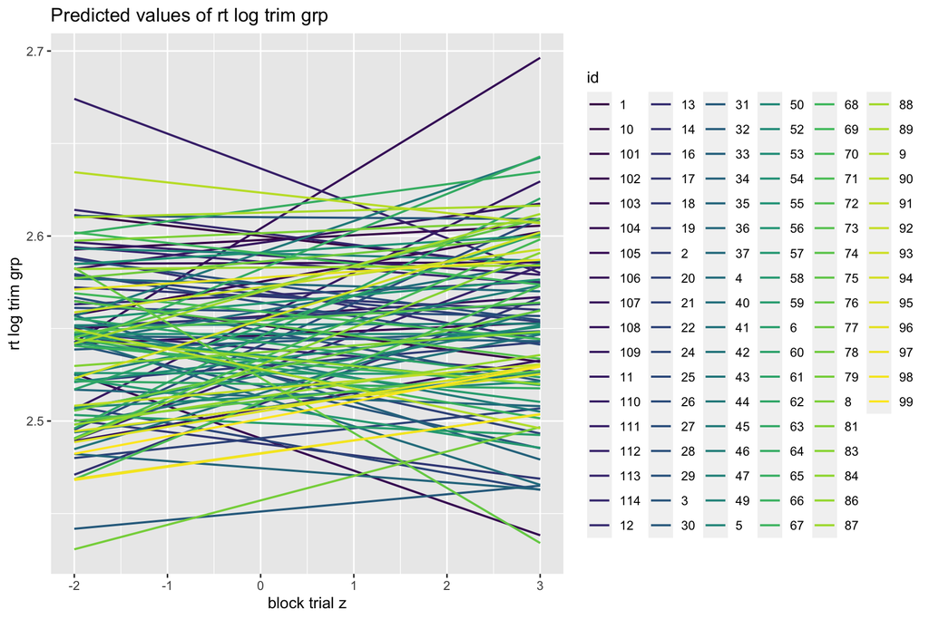

```r
library(sjPlot)
library(sjmisc)
# sjp.lmer(m7, y.offset = .4)
#
# plot_model(m7)

(pp <- plot_model(m7,type="pred",
       terms=c("block_trial_z", "id"),pred.type="re") + scale_color_sjplot(palette = "viridis"))
```

Indeed.

Interim summary: Rather than fitting conditions separately, the model is greatly aided by simply analyzing the number of trials since the most recent no-go. This makes good sense, as this shows linear scaling of the effect rather than blocking it together. This also makes sense, since participants are not aware of what condition they are in and are likely only tracking info about when they last completed a no-go trial.

## m8: Per AMS suggestion, test ixn of block trial and trial number. start with additive effect

```r
minfo[["m8"]] <- c(fixed="Trials from no-go, Trial number", l2="Subject: Intercept, Trials from no-go")

m8 <- lmer(rt_log_trim_grp ~  block_trial_z+trial_z + (1 + block_trial_z | id),
           na.action = na.exclude,
          data = gng_rt, control=lmerControl(optCtrl=list(maxfun=2e4)), REML = FALSE) #bump up iterations)
summary(m8)
```

```
## Linear mixed model fit by maximum likelihood . t-tests use Satterthwaite's method ['lmerModLmerTest']
## Formula: rt_log_trim_grp ~ block_trial_z + trial_z + (1 + block_trial_z |      id)
##    Data: gng_rt
## Control: lmerControl(optCtrl = list(maxfun = 20000))
##
##      AIC      BIC   logLik deviance df.resid
##   -47540   -47485    23777   -47554    19237
##
## Scaled residuals:
##    Min     1Q Median     3Q    Max
## -3.849 -0.637 -0.081  0.568  4.182
##
## Random effects:
##  Groups   Name          Variance Std.Dev. Corr
##  id       (Intercept)   0.001423 0.0377
##           block_trial_z 0.000129 0.0114   -0.02
##  Residual               0.004795 0.0692
## Number of obs: 19244, groups:  id, 103
##
## Fixed effects:
##                Estimate Std. Error        df t value Pr(>|t|)
## (Intercept)    2.55e+00   3.75e-03  1.03e+02  678.61  < 2e-16 ***
## block_trial_z  5.15e-03   1.48e-03  2.20e+02    3.47  0.00062 ***
## trial_z       -3.30e-03   9.70e-04  1.90e+04   -3.40  0.00067 ***
## ---
## Signif. codes:  0 '***' 0.001 '**' 0.01 '*' 0.05 '.' 0.1 ' ' 1
##
## Correlation of Fixed Effects:
##             (Intr) blck__
## block_trl_z -0.018
## trial_z      0.003 -0.563
```

```r
# emmeans(m2, ~cond)



flextable(render_aictab(minfo=minfo, m1, m2, m3,m4,m5,m6,m7, m8)) %>% autofit()
```

| model | fixed | l2 | logLik | AIC | dAIC | df | weight |
| --- | --- | --- | --- | --- | --- | --- | --- |
| m1 | Condition | Subject: Intercept | 23588 | -47163 | 376.52 | 6 | 1.72e-82 |
| m2 | Condition | Subject: Intercept, Condition | 23603 | -47176 | 364.27 | 15 | 7.86e-80 |
| m3 | Condition, Trial | Subject: Intercept, Condition | 23594 | -47156 | 383.49 | 16 | 5.29e-84 |
| m4 | Condition, Trials from no-go | Subject: Intercept, Condition | 23601 | -47169 | 370.53 | 16 | 3.45e-81 |
| m5 | Trials from no-go | Subject: Intercept, Condition | 23610 | -47194 | 345.82 | 13 | 8.00e-76 |
| m6 | Trials from no-go | Subject: Intercept | 23610 | -47212 | 327.82 | 4 | 6.46e-72 |
| m7 | Trials from no-go | Subject: Intercept, Trials from no-go | 23771 | -47530 | 9.58 | 6 | 8.23e-03 |
| m8 | Trials from no-go, Trial number | Subject: Intercept, Trials from no-go | 23777 | -47540 | 0.00 | 7 | 9.92e-01 |

## m9: Per AMS suggestion, test ixn of block trial and trial number

```r
minfo[["m9"]] <- c(fixed="Trials from no-go, Trial number, Trials from no-go x Trial number", l2="Subject: Intercept, Trials from no-go")

m9 <- lmer(rt_log_trim_grp ~  block_trial_z*trial_z + (1 + block_trial_z | id),
           na.action = na.exclude,
          data = gng_rt, control=lmerControl(optCtrl=list(maxfun=2e4)), REML = FALSE) #bump up iterations)
summary(m9)
```

```
## Linear mixed model fit by maximum likelihood . t-tests use Satterthwaite's method ['lmerModLmerTest']
## Formula: rt_log_trim_grp ~ block_trial_z * trial_z + (1 + block_trial_z |      id)
##    Data: gng_rt
## Control: lmerControl(optCtrl = list(maxfun = 20000))
##
##      AIC      BIC   logLik deviance df.resid
##   -47548   -47485    23782   -47564    19236
##
## Scaled residuals:
##    Min     1Q Median     3Q    Max
## -3.876 -0.637 -0.080  0.569  4.127
##
## Random effects:
##  Groups   Name          Variance Std.Dev. Corr
##  id       (Intercept)   0.001423 0.0377
##           block_trial_z 0.000129 0.0114   -0.02
##  Residual               0.004792 0.0692
## Number of obs: 19244, groups:  id, 103
##
## Fixed effects:
##                        Estimate Std. Error        df t value Pr(>|t|)
## (Intercept)            2.54e+00   3.79e-03  1.07e+02  672.06   <2e-16 ***
## block_trial_z          3.53e-03   1.57e-03  2.72e+02    2.26   0.0249 *
## trial_z               -1.91e-03   1.06e-03  1.90e+04   -1.79   0.0728 .
## block_trial_z:trial_z  1.92e-03   5.96e-04  1.90e+04    3.23   0.0013 **
## ---
## Signif. codes:  0 '***' 0.001 '**' 0.01 '*' 0.05 '.' 0.1 ' ' 1
##
## Correlation of Fixed Effects:
##             (Intr) blck__ tril_z
## block_trl_z  0.026
## trial_z     -0.052 -0.617
## blck_trl_:_ -0.134 -0.320  0.408
```

```r
# emmeans(m2, ~cond)



flextable(render_aictab(minfo=minfo, m1, m2, m3,m4,m5,m6,m7, m8,m9)) %>% autofit()
```

| model | fixed | l2 | logLik | AIC | dAIC | df | weight |
| --- | --- | --- | --- | --- | --- | --- | --- |
| m1 | Condition | Subject: Intercept | 23588 | -47163 | 384.94 | 6 | 2.54e-84 |
| m2 | Condition | Subject: Intercept, Condition | 23603 | -47176 | 372.69 | 15 | 1.16e-81 |
| m3 | Condition, Trial | Subject: Intercept, Condition | 23594 | -47156 | 391.90 | 16 | 7.83e-86 |
| m4 | Condition, Trials from no-go | Subject: Intercept, Condition | 23601 | -47169 | 378.94 | 16 | 5.10e-83 |
| m5 | Trials from no-go | Subject: Intercept, Condition | 23610 | -47194 | 354.23 | 13 | 1.18e-77 |
| m6 | Trials from no-go | Subject: Intercept | 23610 | -47212 | 336.24 | 4 | 9.56e-74 |
| m7 | Trials from no-go | Subject: Intercept, Trials from no-go | 23771 | -47530 | 18.00 | 6 | 1.22e-04 |
| m8 | Trials from no-go, Trial number | Subject: Intercept, Trials from no-go | 23777 | -47540 | 8.41 | 7 | 1.47e-02 |
| m9 | Trials from no-go, Trial number, Trials from no-go x Trial number | Subject: Intercept, Trials from no-go | 23782 | -47548 | 0.00 | 8 | 9.85e-01 |

## m10: add random slope of trial_z

```r
minfo[["m10"]] <- c(fixed="Trials from no-go, Trial number, Trials from no-go x Trial number", l2="Subject: Intercept, Trials from no-go, Trial")

m10 <- lmer(rt_log_trim_grp ~  block_trial_z*trial_z + (1 + block_trial_z + trial_z| id),
           na.action = na.exclude,
          data = gng_rt, control=lmerControl(optCtrl=list(maxfun=2e4)), REML = FALSE) #bump up iterations)
summary(m10)
```

```
## Linear mixed model fit by maximum likelihood . t-tests use Satterthwaite's method ['lmerModLmerTest']
## Formula: rt_log_trim_grp ~ block_trial_z * trial_z + (1 + block_trial_z +      trial_z | id)
##    Data: gng_rt
## Control: lmerControl(optCtrl = list(maxfun = 20000))
##
##      AIC      BIC   logLik deviance df.resid
##   -47626   -47539    23824   -47648    19233
##
## Scaled residuals:
##    Min     1Q Median     3Q    Max
## -3.812 -0.635 -0.081  0.568  4.112
##
## Random effects:
##  Groups   Name          Variance Std.Dev. Corr
##  id       (Intercept)   1.43e-03 0.03780
##           block_trial_z 8.62e-05 0.00928  -0.10
##           trial_z       1.46e-04 0.01208   0.06 -0.33
##  Residual               4.75e-03 0.06895
## Number of obs: 19244, groups:  id, 103
##
## Fixed effects:
##                        Estimate Std. Error        df t value Pr(>|t|)
## (Intercept)            2.54e+00   3.79e-03  1.07e+02  670.97   <2e-16 ***
## block_trial_z          3.54e-03   1.42e-03  1.32e+02    2.48   0.0143 *
## trial_z               -1.90e-03   1.59e-03  1.18e+02   -1.19   0.2347
## block_trial_z:trial_z  1.92e-03   5.93e-04  1.89e+04    3.24   0.0012 **
## ---
## Signif. codes:  0 '***' 0.001 '**' 0.01 '*' 0.05 '.' 0.1 ' ' 1
##
## Correlation of Fixed Effects:
##             (Intr) blck__ tril_z
## block_trl_z -0.016
## trial_z      0.012 -0.610
## blck_trl_:_ -0.133 -0.351  0.271
## convergence code: 0
## Model failed to converge with max|grad| = 0.00599081 (tol = 0.002, component 1)
```

```r
# emmeans(m2, ~cond)



flextable(render_aictab(minfo=minfo, m1, m2, m3,m4,m5,m6,m7, m8,m9, m10)) %>% autofit()
```

| model | fixed | l2 | logLik | AIC | dAIC | df | weight |
| --- | --- | --- | --- | --- | --- | --- | --- |
| m1 | Condition | Subject: Intercept | 23588 | -47163 | 462.3 | 6 | 4.05e-101 |
| m2 | Condition | Subject: Intercept, Condition | 23603 | -47176 | 450.1 | 15 | 1.85e-98 |
| m3 | Condition, Trial | Subject: Intercept, Condition | 23594 | -47156 | 469.3 | 16 | 1.25e-102 |
| m4 | Condition, Trials from no-go | Subject: Intercept, Condition | 23601 | -47169 | 456.3 | 16 | 8.13e-100 |
| m5 | Trials from no-go | Subject: Intercept, Condition | 23610 | -47194 | 431.6 | 13 | 1.89e-94 |
| m6 | Trials from no-go | Subject: Intercept | 23610 | -47212 | 413.6 | 4 | 1.52e-90 |
| m7 | Trials from no-go | Subject: Intercept, Trials from no-go | 23771 | -47530 | 95.4 | 6 | 1.94e-21 |
| m8 | Trials from no-go, Trial number | Subject: Intercept, Trials from no-go | 23777 | -47540 | 85.8 | 7 | 2.34e-19 |
| m9 | Trials from no-go, Trial number, Trials from no-go x Trial number | Subject: Intercept, Trials from no-go | 23782 | -47548 | 77.4 | 8 | 1.57e-17 |
| m10 | Trials from no-go, Trial number, Trials from no-go x Trial number | Subject: Intercept, Trials from no-go, Trial | 23824 | -47626 | 0.0 | 11 | 1.00e+00 |

## m11: re-introduce condition as fixed

```r
minfo[["m11"]] <- c(fixed="Trials from no-go, Trial number, Trials from no-go x Trial number, Condition", l2="Subject: Intercept, Trials from no-go, Trial")

m11 <- lmer(rt_log_trim_grp ~  block_trial_z*trial_z + cond + (1 + block_trial_z + trial_z| id),
           na.action = na.exclude,
          data = gng_rt, control=lmerControl(optCtrl=list(maxfun=2e4)), REML = FALSE) #bump up iterations)
summary(m11)
```

```
## Linear mixed model fit by maximum likelihood . t-tests use Satterthwaite's method ['lmerModLmerTest']
## Formula: rt_log_trim_grp ~ block_trial_z * trial_z + cond + (1 + block_trial_z +      trial_z | id)
##    Data: gng_rt
## Control: lmerControl(optCtrl = list(maxfun = 20000))
##
##      AIC      BIC   logLik deviance df.resid
##   -47622   -47512    23825   -47650    19230
##
## Scaled residuals:
##    Min     1Q Median     3Q    Max
## -3.810 -0.635 -0.081  0.567  4.113
##
## Random effects:
##  Groups   Name          Variance Std.Dev. Corr
##  id       (Intercept)   1.43e-03 0.03779
##           block_trial_z 8.62e-05 0.00928  -0.10
##           trial_z       1.46e-04 0.01209   0.06 -0.33
##  Residual               4.75e-03 0.06894
## Number of obs: 19244, groups:  id, 103
##
## Fixed effects:
##                        Estimate Std. Error        df t value Pr(>|t|)
## (Intercept)            2.54e+00   4.76e-03  2.65e+02  533.73   <2e-16 ***
## block_trial_z          3.23e-03   2.30e-03  8.75e+02    1.40   0.1612
## trial_z               -1.64e-03   2.22e-03  4.40e+02   -0.74   0.4606
## condThreeGo            3.25e-03   2.48e-03  1.90e+04    1.31   0.1911
## condFiveGo             2.23e-03   2.88e-03  1.90e+04    0.77   0.4385
## condSevenGo            2.44e-03   3.52e-03  1.90e+04    0.69   0.4886
## block_trial_z:trial_z  1.95e-03   6.17e-04  1.90e+04    3.17   0.0015 **
## ---
## Signif. codes:  0 '***' 0.001 '**' 0.01 '*' 0.05 '.' 0.1 ' ' 1
##
## Correlation of Fixed Effects:
##             (Intr) blck__ tril_z cndThG cndFvG cndSvG
## block_trl_z  0.392
## trial_z     -0.347 -0.818
## condThreeGo -0.505 -0.339  0.301
## condFiveGo  -0.583 -0.589  0.522  0.801
## condSevenGo -0.595 -0.721  0.639  0.754  0.911
## blck_trl_:_ -0.243 -0.426  0.379  0.121  0.208  0.254
```

```r
# emmeans(m2, ~cond)



flextable(render_aictab(minfo=minfo, m1, m2, m3,m4,m5,m6,m7, m8,m9, m10, m11)) %>% autofit()
```

| model | fixed | l2 | logLik | AIC | dAIC | df | weight |
| --- | --- | --- | --- | --- | --- | --- | --- |
| m1 | Condition | Subject: Intercept | 23588 | -47163 | 462.32 | 6 | 3.58e-101 |
| m2 | Condition | Subject: Intercept, Condition | 23603 | -47176 | 450.07 | 15 | 1.64e-98 |
| m3 | Condition, Trial | Subject: Intercept, Condition | 23594 | -47156 | 469.29 | 16 | 1.10e-102 |
| m4 | Condition, Trials from no-go | Subject: Intercept, Condition | 23601 | -47169 | 456.33 | 16 | 7.19e-100 |
| m5 | Trials from no-go | Subject: Intercept, Condition | 23610 | -47194 | 431.62 | 13 | 1.67e-94 |
| m6 | Trials from no-go | Subject: Intercept | 23610 | -47212 | 413.62 | 4 | 1.35e-90 |
| m7 | Trials from no-go | Subject: Intercept, Trials from no-go | 23771 | -47530 | 95.38 | 6 | 1.72e-21 |
| m8 | Trials from no-go, Trial number | Subject: Intercept, Trials from no-go | 23777 | -47540 | 85.80 | 7 | 2.07e-19 |
| m9 | Trials from no-go, Trial number, Trials from no-go x Trial number | Subject: Intercept, Trials from no-go | 23782 | -47548 | 77.39 | 8 | 1.39e-17 |
| m10 | Trials from no-go, Trial number, Trials from no-go x Trial number | Subject: Intercept, Trials from no-go, Trial | 23824 | -47626 | 0.00 | 11 | 8.84e-01 |
| m11 | Trials from no-go, Trial number, Trials from no-go x Trial number, Condition | Subject: Intercept, Trials from no-go, Trial | 23825 | -47622 | 4.06 | 14 | 1.16e-01 |

## m12: add random block_trial as a random slope of condition nested within ID

```r
minfo[["m12"]] <- c(fixed="Trials from no-go, Trial number, Trials from no-go x Trial number", l2="Condition within subject: Trials from no-go\nSubject: Intercept, Trials from no-go, Trial")

m12 <- lmer(rt_log_trim_grp ~  block_trial_z*trial_z + (1 + block_trial_z + trial_z| id) + (1 + block_trial_z | id:cond),
           na.action = na.exclude,
          data = gng_rt, control=lmerControl(optCtrl=list(maxfun=2e4)), REML = FALSE) #bump up iterations)
summary(m12)
```

```
## Linear mixed model fit by maximum likelihood . t-tests use Satterthwaite's method ['lmerModLmerTest']
## Formula: rt_log_trim_grp ~ block_trial_z * trial_z + (1 + block_trial_z +      trial_z | id) + (1 + block_trial_z | id:cond)
##    Data: gng_rt
## Control: lmerControl(optCtrl = list(maxfun = 20000))
##
##      AIC      BIC   logLik deviance df.resid
##   -47644   -47533    23836   -47672    19230
##
## Scaled residuals:
##    Min     1Q Median     3Q    Max
## -3.858 -0.633 -0.081  0.565  4.108
##
## Random effects:
##  Groups   Name          Variance Std.Dev. Corr
##  id:cond  (Intercept)   3.64e-05 0.00603
##           block_trial_z 3.16e-05 0.00562  -0.24
##  id       (Intercept)   1.41e-03 0.03761
##           block_trial_z 5.48e-05 0.00740  -0.17
##           trial_z       1.28e-04 0.01130   0.10 -0.22
##  Residual               4.72e-03 0.06868
## Number of obs: 19244, groups:  id:cond, 412; id, 103
##
## Fixed effects:
##                        Estimate Std. Error        df t value Pr(>|t|)
## (Intercept)            2.54e+00   3.79e-03  1.07e+02  671.30  < 2e-16 ***
## block_trial_z          3.65e-03   1.44e-03  1.32e+02    2.55  0.01208 *
## trial_z               -1.87e-03   1.60e-03  1.20e+02   -1.17  0.24407
## block_trial_z:trial_z  1.99e-03   5.97e-04  1.68e+04    3.33  0.00088 ***
## ---
## Signif. codes:  0 '***' 0.001 '**' 0.01 '*' 0.05 '.' 0.1 ' ' 1
##
## Correlation of Fixed Effects:
##             (Intr) blck__ tril_z
## block_trl_z -0.026
## trial_z      0.019 -0.616
## blck_trl_:_ -0.134 -0.359  0.290
```

```r
# emmeans(m2, ~cond)



flextable(render_aictab(minfo=minfo, m1, m2, m3,m4,m5,m6,m7, m8,m9, m10, m11, m12)) %>% autofit()
```

| model | fixed | l2 | logLik | AIC | dAIC | df | weight |
| --- | --- | --- | --- | --- | --- | --- | --- |
| m1 | Condition | Subject: Intercept | 23588 | -47163 | 480.1 | 6 | 5.65e-105 |
| m2 | Condition | Subject: Intercept, Condition | 23603 | -47176 | 467.8 | 15 | 2.58e-102 |
| m3 | Condition, Trial | Subject: Intercept, Condition | 23594 | -47156 | 487.0 | 16 | 1.74e-106 |
| m4 | Condition, Trials from no-go | Subject: Intercept, Condition | 23601 | -47169 | 474.1 | 16 | 1.13e-103 |
| m5 | Trials from no-go | Subject: Intercept, Condition | 23610 | -47194 | 449.4 | 13 | 2.63e-98 |
| m6 | Trials from no-go | Subject: Intercept | 23610 | -47212 | 431.4 | 4 | 2.12e-94 |
| m7 | Trials from no-go | Subject: Intercept, Trials from no-go | 23771 | -47530 | 113.1 | 6 | 2.70e-25 |
| m8 | Trials from no-go, Trial number | Subject: Intercept, Trials from no-go | 23777 | -47540 | 103.6 | 7 | 3.26e-23 |
| m9 | Trials from no-go, Trial number, Trials from no-go x Trial number | Subject: Intercept, Trials from no-go | 23782 | -47548 | 95.1 | 8 | 2.19e-21 |
| m10 | Trials from no-go, Trial number, Trials from no-go x Trial number | Subject: Intercept, Trials from no-go, Trial | 23824 | -47626 | 17.8 | 11 | 1.39e-04 |
| m11 | Trials from no-go, Trial number, Trials from no-go x Trial number, Condition | Subject: Intercept, Trials from no-go, Trial | 23825 | -47622 | 21.8 | 14 | 1.83e-05 |
| m12 | Trials from no-go, Trial number, Trials from no-go x Trial number | Condition within subject: Trials from no-go Subject: Intercept, Trials from no-go, Trial | 23836 | -47644 | 0.0 | 14 | 1.00e+00 |

## m13: add previous error as fixed

```r
minfo[["m13"]] <- c(fixed="Trials from no-go, Trial number, Trials from no-go x Trial number, Previous error",
                    l2="Condition within subject: Trials from no-go\nSubject: Intercept, Trials from no-go, Trial")

m13 <- lmer(rt_log_trim_grp ~  block_trial_z*trial_z + prev_error + (1 + block_trial_z + trial_z| id) + (1 + block_trial_z | id:cond),
           na.action = na.exclude,
          data = gng_rt, control=lmerControl(optCtrl=list(maxfun=2e4)), REML = FALSE) #bump up iterations)
summary(m13)
```

```
## Linear mixed model fit by maximum likelihood . t-tests use Satterthwaite's method ['lmerModLmerTest']
## Formula: rt_log_trim_grp ~ block_trial_z * trial_z + prev_error + (1 +      block_trial_z + trial_z | id) + (1 + block_trial_z | id:cond)
##    Data: gng_rt
## Control: lmerControl(optCtrl = list(maxfun = 20000))
##
##      AIC      BIC   logLik deviance df.resid
##   -47333   -47215    23681   -47363    19059
##
## Scaled residuals:
##    Min     1Q Median     3Q    Max
## -3.869 -0.636 -0.079  0.567  4.149
##
## Random effects:
##  Groups   Name          Variance Std.Dev. Corr
##  id:cond  (Intercept)   4.01e-05 0.00633
##           block_trial_z 3.00e-05 0.00548  -0.27
##  id       (Intercept)   1.41e-03 0.03756
##           block_trial_z 5.68e-05 0.00753  -0.16
##           trial_z       1.20e-04 0.01094   0.08 -0.19
##  Residual               4.69e-03 0.06846
## Number of obs: 19074, groups:  id:cond, 412; id, 103
##
## Fixed effects:
##                        Estimate Std. Error        df t value Pr(>|t|)
## (Intercept)            2.54e+00   3.79e-03  1.07e+02  671.70   <2e-16 ***
## block_trial_z          4.46e-03   1.46e-03  1.36e+02    3.06   0.0026 **
## trial_z               -2.29e-03   1.59e-03  1.23e+02   -1.44   0.1513
## prev_error             7.29e-03   2.45e-03  1.87e+04    2.97   0.0030 **
## block_trial_z:trial_z  1.48e-03   6.02e-04  1.68e+04    2.46   0.0139 *
## ---
## Signif. codes:  0 '***' 0.001 '**' 0.01 '*' 0.05 '.' 0.1 ' ' 1
##
## Correlation of Fixed Effects:
##             (Intr) blck__ tril_z prv_rr
## block_trl_z -0.026
## trial_z      0.008 -0.614
## prev_error  -0.028  0.116 -0.093
## blck_trl_:_ -0.134 -0.361  0.293 -0.016
## convergence code: 0
## Model failed to converge with max|grad| = 0.00692043 (tol = 0.002, component 1)
```

```r
# emmeans(m2, ~cond)



flextable(render_aictab(minfo=minfo, m1, m2, m3,m4,m5,m6,m7, m8,m9, m10, m11, m12, m13)) %>% autofit()
```

| model | fixed | l2 | logLik | AIC | dAIC | df | weight |
| --- | --- | --- | --- | --- | --- | --- | --- |
| m1 | Condition | Subject: Intercept | 23588 | -47163 | 480.1 | 6 | 5.65e-105 |
| m2 | Condition | Subject: Intercept, Condition | 23603 | -47176 | 467.8 | 15 | 2.58e-102 |
| m3 | Condition, Trial | Subject: Intercept, Condition | 23594 | -47156 | 487.0 | 16 | 1.74e-106 |
| m4 | Condition, Trials from no-go | Subject: Intercept, Condition | 23601 | -47169 | 474.1 | 16 | 1.13e-103 |
| m5 | Trials from no-go | Subject: Intercept, Condition | 23610 | -47194 | 449.4 | 13 | 2.63e-98 |
| m6 | Trials from no-go | Subject: Intercept | 23610 | -47212 | 431.4 | 4 | 2.12e-94 |
| m7 | Trials from no-go | Subject: Intercept, Trials from no-go | 23771 | -47530 | 113.1 | 6 | 2.70e-25 |
| m8 | Trials from no-go, Trial number | Subject: Intercept, Trials from no-go | 23777 | -47540 | 103.6 | 7 | 3.26e-23 |
| m9 | Trials from no-go, Trial number, Trials from no-go x Trial number | Subject: Intercept, Trials from no-go | 23782 | -47548 | 95.1 | 8 | 2.19e-21 |
| m10 | Trials from no-go, Trial number, Trials from no-go x Trial number | Subject: Intercept, Trials from no-go, Trial | 23824 | -47626 | 17.8 | 11 | 1.39e-04 |
| m11 | Trials from no-go, Trial number, Trials from no-go x Trial number, Condition | Subject: Intercept, Trials from no-go, Trial | 23825 | -47622 | 21.8 | 14 | 1.83e-05 |
| m12 | Trials from no-go, Trial number, Trials from no-go x Trial number | Condition within subject: Trials from no-go Subject: Intercept, Trials from no-go, Trial | 23836 | -47644 | 0.0 | 14 | 1.00e+00 |
| m13 | Trials from no-go, Trial number, Trials from no-go x Trial number, Previous error | Condition within subject: Trials from no-go Subject: Intercept, Trials from no-go, Trial | 23681 | -47333 | 310.8 | 15 | 3.17e-68 |

## m14: prev_error ixn

```r
minfo[["m14"]] <- c(fixed="Trials from no-go, Trial number, Trials from no-go x Trial number, Previous error, Trials from no-go x Previous error",
                    l2="Condition within subject: Trials from no-go\nSubject: Intercept, Trials from no-go, Trial, Previous error")

m14 <- lmer(rt_log_trim_grp ~  block_trial_z*trial_z + block_trial_z*prev_error + (1 + block_trial_z + trial_z + prev_error | id) + (1 + block_trial_z | id:cond),
           na.action = na.exclude,
          data = gng_rt, control=lmerControl(optCtrl=list(maxfun=2e4)), REML = FALSE) #bump up iterations)
summary(m14)
```

```
## Linear mixed model fit by maximum likelihood . t-tests use Satterthwaite's method ['lmerModLmerTest']
## Formula: rt_log_trim_grp ~ block_trial_z * trial_z + block_trial_z * prev_error +
##     (1 + block_trial_z + trial_z + prev_error | id) + (1 + block_trial_z |      id:cond)
##    Data: gng_rt
## Control: lmerControl(optCtrl = list(maxfun = 20000))
##
##      AIC      BIC   logLik deviance df.resid
##   -47390   -47233    23715   -47430    19054
##
## Scaled residuals:
##    Min     1Q Median     3Q    Max
## -3.965 -0.634 -0.078  0.566  4.175
##
## Random effects:
##  Groups   Name          Variance Std.Dev. Corr
##  id:cond  (Intercept)   3.85e-05 0.00621
##           block_trial_z 3.01e-05 0.00549  -0.23
##  id       (Intercept)   1.41e-03 0.03752
##           block_trial_z 4.52e-05 0.00673  -0.18
##           trial_z       1.17e-04 0.01083   0.08 -0.11
##           prev_error    8.72e-04 0.02953   0.06 -0.15 -0.03
##  Residual               4.65e-03 0.06820
## Number of obs: 19074, groups:  id:cond, 412; id, 103
##
## Fixed effects:
##                           Estimate Std. Error        df t value Pr(>|t|)
## (Intercept)               2.54e+00   3.78e-03  1.07e+02  672.58   <2e-16 ***
## block_trial_z             4.59e-03   1.42e-03  1.36e+02    3.23   0.0015 **
## trial_z                  -2.26e-03   1.58e-03  1.21e+02   -1.43   0.1545
## prev_error                5.62e-03   4.04e-03  1.03e+02    1.39   0.1669
## block_trial_z:trial_z     1.45e-03   6.00e-04  1.67e+04    2.41   0.0159 *
## block_trial_z:prev_error -5.08e-03   2.74e-03  1.40e+04   -1.85   0.0638 .
## ---
## Signif. codes:  0 '***' 0.001 '**' 0.01 '*' 0.05 '.' 0.1 ' ' 1
##
## Correlation of Fixed Effects:
##               (Intr) blck__ tril_z prv_rr blck_trl_z:t_
## block_trl_z   -0.026
## trial_z        0.009 -0.600
## prev_error     0.027  0.005 -0.067
## blck_trl_z:t_ -0.133 -0.368  0.292 -0.007
## blck_trl_z:p_ -0.001 -0.089  0.015  0.190  0.015
## convergence code: 0
## Model failed to converge with max|grad| = 0.00794371 (tol = 0.002, component 1)
```

```r
# emmeans(m2, ~cond)



flextable(render_aictab(minfo=minfo, m1, m2, m3,m4,m5,m6,m7, m8,m9, m10, m11, m12, m13, m14)) %>% autofit()
```

| model | fixed | l2 | logLik | AIC | dAIC | df | weight |
| --- | --- | --- | --- | --- | --- | --- | --- |
| m1 | Condition | Subject: Intercept | 23588 | -47163 | 480.1 | 6 | 5.65e-105 |
| m2 | Condition | Subject: Intercept, Condition | 23603 | -47176 | 467.8 | 15 | 2.58e-102 |
| m3 | Condition, Trial | Subject: Intercept, Condition | 23594 | -47156 | 487.0 | 16 | 1.74e-106 |
| m4 | Condition, Trials from no-go | Subject: Intercept, Condition | 23601 | -47169 | 474.1 | 16 | 1.13e-103 |
| m5 | Trials from no-go | Subject: Intercept, Condition | 23610 | -47194 | 449.4 | 13 | 2.63e-98 |
| m6 | Trials from no-go | Subject: Intercept | 23610 | -47212 | 431.4 | 4 | 2.12e-94 |
| m7 | Trials from no-go | Subject: Intercept, Trials from no-go | 23771 | -47530 | 113.1 | 6 | 2.70e-25 |
| m8 | Trials from no-go, Trial number | Subject: Intercept, Trials from no-go | 23777 | -47540 | 103.6 | 7 | 3.26e-23 |
| m9 | Trials from no-go, Trial number, Trials from no-go x Trial number | Subject: Intercept, Trials from no-go | 23782 | -47548 | 95.1 | 8 | 2.19e-21 |
| m10 | Trials from no-go, Trial number, Trials from no-go x Trial number | Subject: Intercept, Trials from no-go, Trial | 23824 | -47626 | 17.8 | 11 | 1.39e-04 |
| m11 | Trials from no-go, Trial number, Trials from no-go x Trial number, Condition | Subject: Intercept, Trials from no-go, Trial | 23825 | -47622 | 21.8 | 14 | 1.83e-05 |
| m12 | Trials from no-go, Trial number, Trials from no-go x Trial number | Condition within subject: Trials from no-go Subject: Intercept, Trials from no-go, Trial | 23836 | -47644 | 0.0 | 14 | 1.00e+00 |
| m13 | Trials from no-go, Trial number, Trials from no-go x Trial number, Previous error | Condition within subject: Trials from no-go Subject: Intercept, Trials from no-go, Trial | 23681 | -47333 | 310.8 | 15 | 3.17e-68 |
| m14 | Trials from no-go, Trial number, Trials from no-go x Trial number, Previous error, Trials from no-go x Previous error | Condition within subject: Trials from no-go Subject: Intercept, Trials from no-go, Trial, Previous error | 23715 | -47390 | 253.6 | 20 | 8.51e-56 |

## m15: add previous error as random within ID

```r
minfo[["m15"]] <- c(fixed="Trials from no-go, Trial number, Trials from no-go x Trial number",
                    l2="Condition within subject: Trials from no-go\nSubject: Intercept, Trials from no-go, Trial, Previous error")

m15 <- lmer(rt_log_trim_grp ~  block_trial_z*trial_z  + (1 + block_trial_z + trial_z + prev_error | id) + (1 + block_trial_z | id:cond),
           na.action = na.exclude,
          data = gng_rt, control=lmerControl(optCtrl=list(maxfun=2e4)), REML = FALSE) #bump up iterations)
```

```
## boundary (singular) fit: see ?isSingular
```

```r
summary(m15)
```

```
## Linear mixed model fit by maximum likelihood . t-tests use Satterthwaite's method ['lmerModLmerTest']
## Formula: rt_log_trim_grp ~ block_trial_z * trial_z + (1 + block_trial_z +      trial_z + prev_error | id) + (1 + block_trial_z | id:cond)
##    Data: gng_rt
## Control: lmerControl(optCtrl = list(maxfun = 20000))
##
##      AIC      BIC   logLik deviance df.resid
##   -47373   -47232    23704   -47409    19056
##
## Scaled residuals:
##    Min     1Q Median     3Q    Max
## -3.952 -0.636 -0.080  0.567  4.190
##
## Random effects:
##  Groups   Name          Variance Std.Dev. Corr
##  id:cond  (Intercept)   0.00e+00 0.00000
##           block_trial_z 3.64e-05 0.00603   NaN
##  id       (Intercept)   1.42e-03 0.03771
##           block_trial_z 6.00e-05 0.00774  -0.11
##           trial_z       1.36e-04 0.01168   0.05 -0.30
##           prev_error    9.15e-04 0.03024   0.05 -0.09 -0.02
##  Residual               4.67e-03 0.06834
## Number of obs: 19074, groups:  id:cond, 412; id, 103
##
## Fixed effects:
##                        Estimate Std. Error        df t value Pr(>|t|)
## (Intercept)            2.54e+00   3.78e-03  1.06e+02  672.48   <2e-16 ***
## block_trial_z          4.32e-03   1.39e-03  1.30e+02    3.10   0.0024 **
## trial_z               -2.04e-03   1.57e-03  1.18e+02   -1.30   0.1974
## block_trial_z:trial_z  1.47e-03   5.99e-04  1.01e+04    2.46   0.0141 *
## ---
## Signif. codes:  0 '***' 0.001 '**' 0.01 '*' 0.05 '.' 0.1 ' ' 1
##
## Correlation of Fixed Effects:
##             (Intr) blck__ tril_z
## block_trl_z -0.016
## trial_z      0.003 -0.600
## blck_trl_:_ -0.129 -0.341  0.268
## convergence code: 0
## boundary (singular) fit: see ?isSingular
```

```r
# emmeans(m2, ~cond)



flextable(render_aictab(minfo=minfo, m1, m2, m3,m4,m5,m6,m7, m8,m9, m10, m11, m12, m13, m14,m15)) %>% autofit() #%>% save_as_docx(path = "~/Desktop/emmeans_gng_aictable.docx") #save for inclusion in supplement
```

| model | fixed | l2 | logLik | AIC | dAIC | df | weight |
| --- | --- | --- | --- | --- | --- | --- | --- |
| m1 | Condition | Subject: Intercept | 23588 | -47163 | 480.1 | 6 | 5.65e-105 |
| m2 | Condition | Subject: Intercept, Condition | 23603 | -47176 | 467.8 | 15 | 2.58e-102 |
| m3 | Condition, Trial | Subject: Intercept, Condition | 23594 | -47156 | 487.0 | 16 | 1.74e-106 |
| m4 | Condition, Trials from no-go | Subject: Intercept, Condition | 23601 | -47169 | 474.1 | 16 | 1.13e-103 |
| m5 | Trials from no-go | Subject: Intercept, Condition | 23610 | -47194 | 449.4 | 13 | 2.63e-98 |
| m6 | Trials from no-go | Subject: Intercept | 23610 | -47212 | 431.4 | 4 | 2.12e-94 |
| m7 | Trials from no-go | Subject: Intercept, Trials from no-go | 23771 | -47530 | 113.1 | 6 | 2.70e-25 |
| m8 | Trials from no-go, Trial number | Subject: Intercept, Trials from no-go | 23777 | -47540 | 103.6 | 7 | 3.26e-23 |
| m9 | Trials from no-go, Trial number, Trials from no-go x Trial number | Subject: Intercept, Trials from no-go | 23782 | -47548 | 95.1 | 8 | 2.19e-21 |
| m10 | Trials from no-go, Trial number, Trials from no-go x Trial number | Subject: Intercept, Trials from no-go, Trial | 23824 | -47626 | 17.8 | 11 | 1.39e-04 |
| m11 | Trials from no-go, Trial number, Trials from no-go x Trial number, Condition | Subject: Intercept, Trials from no-go, Trial | 23825 | -47622 | 21.8 | 14 | 1.83e-05 |
| m12 | Trials from no-go, Trial number, Trials from no-go x Trial number | Condition within subject: Trials from no-go Subject: Intercept, Trials from no-go, Trial | 23836 | -47644 | 0.0 | 14 | 1.00e+00 |
| m13 | Trials from no-go, Trial number, Trials from no-go x Trial number, Previous error | Condition within subject: Trials from no-go Subject: Intercept, Trials from no-go, Trial | 23681 | -47333 | 310.8 | 15 | 3.17e-68 |
| m14 | Trials from no-go, Trial number, Trials from no-go x Trial number, Previous error, Trials from no-go x Previous error | Condition within subject: Trials from no-go Subject: Intercept, Trials from no-go, Trial, Previous error | 23715 | -47390 | 253.6 | 20 | 8.51e-56 |
| m15 | Trials from no-go, Trial number, Trials from no-go x Trial number | Condition within subject: Trials from no-go Subject: Intercept, Trials from no-go, Trial, Previous error | 23704 | -47373 | 270.6 | 18 | 1.76e-59 |

m12 is winner. grab relevant statistics for results

```r
test(emtrends(m12, ~trial_z, var = "block_trial_z", at = list(trial_z = c(-2, -1, 1, 2))))
```

```
## Note: D.f. calculations have been disabled because the number of observations exceeds 3000.
## To enable adjustments, add the argument 'pbkrtest.limit = 19244' (or larger)
## [or, globally, 'set emm_options(pbkrtest.limit = 19244)' or larger];
## but be warned that this may result in large computation time and memory use.
```

```
## Note: D.f. calculations have been disabled because the number of observations exceeds 3000.
## To enable adjustments, add the argument 'lmerTest.limit = 19244' (or larger)
## [or, globally, 'set emm_options(lmerTest.limit = 19244)' or larger];
## but be warned that this may result in large computation time and memory use.
```

```
##  trial_z block_trial_z.trend      SE  df z.ratio p.value
##       -2            -0.00032 0.00217 Inf -0.150  0.8840
##       -1             0.00167 0.00174 Inf  0.960  0.3380
##        1             0.00564 0.00134 Inf  4.200  <.0001
##        2             0.00763 0.00150 Inf  5.080  <.0001
##
## Degrees-of-freedom method: asymptotic
```

```r
test(emtrends(m12, ~block_trial_z, var = "trial_z", at = list(block_trial_z = c(-1, 1))))
```

```
## Note: D.f. calculations have been disabled because the number of observations exceeds 3000.
## To enable adjustments, add the argument 'pbkrtest.limit = 19244' (or larger)
## [or, globally, 'set emm_options(pbkrtest.limit = 19244)' or larger];
## but be warned that this may result in large computation time and memory use.
## Note: D.f. calculations have been disabled because the number of observations exceeds 3000.
## To enable adjustments, add the argument 'lmerTest.limit = 19244' (or larger)
## [or, globally, 'set emm_options(lmerTest.limit = 19244)' or larger];
## but be warned that this may result in large computation time and memory use.
```

```
##  block_trial_z trial_z.trend      SE  df z.ratio p.value
##             -1      -0.00386 0.00154 Inf -2.511  0.0120
##              1       0.00011 0.00186 Inf  0.061  0.9520
##
## Degrees-of-freedom method: asymptotic
```

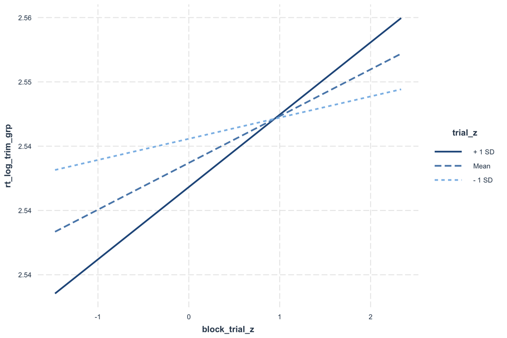

```r
library(interactions)

interact_plot(m12, pred = "block_trial_z", modx = "trial_z")
```

```r
flextable(anova(m12) %>% tibble::rownames_to_column("Effect")) %>% autofit() #lmerTest reports Satterthwaite degrees of freedom
```

| Effect | Sum Sq | Mean Sq | NumDF | DenDF | F value | Pr(>F) |
| --- | --- | --- | --- | --- | --- | --- |
| block_trial_z | 0.03055 | 0.03055 | 1 | 132 | 6.48 | 0.012078 |
| trial_z | 0.00646 | 0.00646 | 1 | 120 | 1.37 | 0.244071 |
| block_trial_z:trial_z | 0.05217 | 0.05217 | 1 | 16764 | 11.06 | 0.000884 |

```r
flextable(car::Anova(m1, type=3)) %>% autofit()
```

| Chisq | Df | Pr(>Chisq) |
| --- | --- | --- |
| 356756.7 | 1 | 0.000000 |
| 17.9 | 3 | 0.000463 |

```r
#
# quantile(gng_rt$prev_rt, .16, na.rm = TRUE) # to get what is equivalent to -1, 1 in z scores
# quantile(gng_rt$prev_rt, .84, na.rm = TRUE)
# test(emtrends(m19, ~prev_rt, var = "block_trial_z", at = list(prev_rt = c(.26, .42))))
# random.effects(m19)
```